# Manipulace s daty pomocí tidyverse

Kateřina Večerková vecerkok@vscht.cz

2025-06-19

# Práce s daty pomocí `tidyverse`

`tidyverse` je sada balíčků v R určených pro datovou vědu. Všechny balíčky v `tidyverse` sdílejí společné principy, syntaxi a datové struktury, což umožňuje jejich snadné kombinování. `tidyverse` usnadňuje běžné úlohy jako manipulaci s daty, vizualizaci a analýzu.

Balíčky v `tidyverse` zahrnují: - `readr`: import dat - `dplyr`: manipulace s daty - `tidyr`: úprava dat do „tidy“ formátu - `ggplot2`: vizualizace dat - `forcats`: práce s kategoriálními daty - `stringr`: práce s textem - `lubridate`: práce s datem a časem - `tibble`: moderní datové rámce - `purrr`: funkcionální programování

Pro instalaci celého `tidyverse` použijte:

```r
install.packages("tidyverse")
library(tidyverse)
```

## Načítání dat ze souboru pomocí `readr`

Balíček `readr` nabízí funkce pro import a export tabulkových dat v různých formátech, např. CSV, TSV nebo soubory s jinými oddělovači.

```bash
head iris.csv
```

```
## "sepal.length","sepal.width","petal.length","petal.width","variety"
## 5.1,3.5,1.4,.2,"setosa"
## 4.9,3,1.4,.2,"setosa"
## 4.7,3.2,1.3,.2,"setosa"
## 4.6,3.1,1.5,.2,"setosa"
## 5,3.6,1.4,.2,"setosa"
## 5.4,3.9,1.7,.4,"setosa"
## 4.6,3.4,1.4,.3,"setosa"
## 5,3.4,1.5,.2,"setosa"
## 4.4,2.9,1.4,.2,"setosa"
```

CSV (comma-separated values) je běžný formát pro tabulková data. První řádek většinou obsahuje názvy sloupců, další řádky odpovídající data oddělená čárkami. Načteme tento dataset ze souboru `iris.csv` do R:

```r
# načtení balíčku readr
library(readr)
# načtení CSV dat
iris <- readr::read_csv("iris.csv")
# zobrazíme prvních 5 řádků
head(iris)
```

[output not shown]

Další často používaný formát je TSV (tab-separated values), kde místo čárky sloupce odděluje tabulátor `\t`.

```r
# načtení TSV dat
iris <- readr::read_tsv("iris.tsv")
head(iris)
```

```
## # A tibble: 6 × 5
##   sepal.length sepal.width petal.length petal.width variety
##          <dbl>       <dbl>        <dbl>       <dbl> <chr>
## 1          5.1         3.5          1.4         0.2 setosa
## 2          4.9         3            1.4         0.2 setosa
## 3          4.7         3.2          1.3         0.2 setosa
## 4          4.6         3.1          1.5         0.2 setosa
## 5          5           3.6          1.4         0.2 setosa
## 6          5.4         3.9          1.7         0.4 setosa
```

## Manipulace s daty pomocí `dplyr`

```r
library(dplyr)
```

### 1. Filtrování řádků

Vybereme pouze řádky, kde je druh `"setosa"`.

```r
setosa_iris <- iris %>% dplyr::filter(variety == "setosa")
head(setosa_iris)
```

```
## # A tibble: 6 × 5
##   sepal.length sepal.width petal.length petal.width variety
##          <dbl>       <dbl>        <dbl>       <dbl> <chr>
## 1          5.1         3.5          1.4         0.2 setosa
## 2          4.9         3            1.4         0.2 setosa
## 3          4.7         3.2          1.3         0.2 setosa
## 4          4.6         3.1          1.5         0.2 setosa
## 5          5           3.6          1.4         0.2 setosa
## 6          5.4         3.9          1.7         0.4 setosa
```

Operátor `%>%` (pipe) vyjadřuje posloupnost operací. Není nutné uvádět název balíčku, ale zde to děláme pro ukázku.

### 2. Výběr sloupců

Vybereme pouze sloupce sepal.length a sepal.width.

```r
sepal_data <- iris %>% dplyr::select(sepal.length, sepal.width)
head(sepal_data)
```

```
## # A tibble: 6 × 2
##   sepal.length sepal.width
##          <dbl>       <dbl>
## 1          5.1         3.5
## 2          4.9         3
## 3          4.7         3.2
## 4          4.6         3.1
## 5          5           3.6
## 6          5.4         3.9
```

### 3. Přidání nových sloupců

Vytvoříme nový sloupec jako poměr délky a šířky okvětního lístku.

```r
iris <- iris %>% dplyr::mutate(petal.ratio = petal.length / petal.width)
head(iris)
```

```
## # A tibble: 6 × 6
##   sepal.length sepal.width petal.length petal.width variety petal.ratio
##          <dbl>       <dbl>        <dbl>       <dbl> <chr>         <dbl>
## 1          5.1         3.5          1.4         0.2 setosa         7
## 2          4.9         3            1.4         0.2 setosa         7
## 3          4.7         3.2          1.3         0.2 setosa         6.5
## 4          4.6         3.1          1.5         0.2 setosa         7.5
## 5          5           3.6          1.4         0.2 setosa         7
## 6          5.4         3.9          1.7         0.4 setosa         4.25
```

### 4. Shrnutí dat

Spočítáme průměr a směrodatnou odchylku délky kalichu podle druhu.

```r
summary_stats <- iris %>%
  dplyr::group_by(variety) %>%
  dplyr::summarize(
    mean_sepal.length = mean(sepal.length),
    sd_sepal.length = sd(sepal.length)
  )
summary_stats
```

```
## # A tibble: 3 × 3
##   variety    mean_sepal.length sd_sepal.length
##   <chr>                  <dbl>           <dbl>
## 1 setosa                  5.01           0.352
## 2 versicolor              5.94           0.516
## 3 virginica               6.59           0.636
```

### 5. Řazení řádků

Seřadíme data podle délky kalichu sestupně.

```r
sorted_iris <- iris %>% dplyr::arrange(desc(sepal.length))
head(sorted_iris)
```

```
## # A tibble: 6 × 6
##   sepal.length sepal.width petal.length petal.width variety   petal.ratio
##          <dbl>       <dbl>        <dbl>       <dbl> <chr>           <dbl>
## 1          7.9         3.8          6.4         2   virginica        3.2
## 2          7.7         3.8          6.7         2.2 virginica        3.05
## 3          7.7         2.6          6.9         2.3 virginica        3
## 4          7.7         2.8          6.7         2   virginica        3.35
## 5          7.7         3            6.1         2.3 virginica        2.65
## 6          7.6         3            6.6         2.1 virginica        3.14
```

### 6. Skupinové shrnutí

Pro každý druh spočítáme počet případů, kdy délka okvětního lístku > 4.

```r
count_petal_length <- iris %>%
  dplyr::filter(petal.length > 4) %>%
  dplyr::group_by(variety) %>%
  dplyr::summarize(count = n())
count_petal_length
```

```
## # A tibble: 2 × 2
##   variety    count
##   <chr>      <int>
## 1 versicolor    34
## 2 virginica     50
```

### 7. Přejmenování sloupců

Přejmenujeme sloupce sepal.length → sepal_length a sepal.width → sepal_width.

```r
iris <- iris %>% dplyr::rename(
  sepal_length = sepal.length,
  sepal_width = sepal.width
)
colnames(iris)
```

```
## [1] "sepal_length" "sepal_width"  "petal.length" "petal.width"  "variety"
## [6] "petal.ratio"
```

### 8. Filtrování a přidání sloupce

Vybereme pouze druh `"virginica"` a přidáme sloupec, který říká, zda je délka kalichu > 6.

```r
virginica_iris <- iris %>%
  dplyr::filter(variety == "virginica") %>%
  dplyr::mutate(sepal_length_over_6 = sepal_length > 6)
head(virginica_iris)
```

```
## # A tibble: 6 × 7
##   sepal_length sepal_width petal.length petal.width variety   petal.ratio
##          <dbl>       <dbl>        <dbl>       <dbl> <chr>           <dbl>
## 1          6.3         3.3          6           2.5 virginica        2.4
## 2          5.8         2.7          5.1         1.9 virginica        2.68
## 3          7.1         3            5.9         2.1 virginica        2.81
## 4          6.3         2.9          5.6         1.8 virginica        3.11
## 5          6.5         3            5.8         2.2 virginica        2.64
## 6          7.6         3            6.6         2.1 virginica        3.14
## # ℹ 1 more variable: sepal_length_over_6 <lgl>
```

### 9. Náhodný výběr řádků

Náhodně vybereme 10 řádků z datasetu.

```r
sampled_iris <- iris %>% dplyr::sample_n(10)
show(sampled_iris)
```

```
## # A tibble: 10 × 6
##    sepal_length sepal_width petal.length petal.width variety    petal.ratio
##           <dbl>       <dbl>        <dbl>       <dbl> <chr>            <dbl>
##  1          4.4         3.2          1.3         0.2 setosa            6.5
##  2          5.5         2.4          3.7         1   versicolor        3.7
##  3          5           3.4          1.5         0.2 setosa            7.5
##  4          4.9         3.1          1.5         0.1 setosa           15
##  5          7.1         3            5.9         2.1 virginica         2.81
##  6          6.3         2.7          4.9         1.8 virginica         2.72
##  7          4.9         2.4          3.3         1   versicolor        3.3
##  8          4.7         3.2          1.3         0.2 setosa            6.5
##  9          5.4         3.9          1.7         0.4 setosa            4.25
## 10          6.4         3.2          4.5         1.5 versicolor        3
```

### 10. Kombinace více funkcí `dplyr`

Vytvoříme nový dataset s druhem `"versicolor"`, vybereme sloupce petal.length a petal.width a seřadíme podle šířky okvětního lístku vzestupně.

```r
versicolor_sorted <- iris %>%
  dplyr::filter(variety == "versicolor") %>%
  dplyr::select(petal.length, petal.width) %>%
  dplyr::arrange(petal.width)
head(versicolor_sorted)
```

```
## # A tibble: 6 × 2
##   petal.length petal.width
##          <dbl>       <dbl>
## 1          3.3           1
## 2          3.5           1
## 3          4             1
## 4          4.1           1
## 5          3.5           1
## 6          3.7           1
```

## Úprava dat pomocí `tidyr`

#### **Široký formát (Wide Format)**

V širokém formátu je každá proměnná rozložena do samostatného sloupce a každé pozorování (nebo jednotka) je reprezentováno jedním řádkem.

**Příklad s datasetem `iris`:**

| Druh | Délka kalichu | Šířka kalichu | Délka okvětního lístku | Šířka okvětního lístku |
| --- | --- | --- | --- | --- |
| setosa | 5.1 | 3.5 | 1.4 | 0.2 |
| versicolor | 7.0 | 3.2 | 4.7 | 1.4 |
| virginica | 6.3 | 3.3 | 6.0 | 2.5 |

Každý sloupec zde reprezentuje jinou proměnnou a každý řádek jedno pozorování.

#### **Dlouhý formát (Long Format)**

V dlouhém formátu každý řádek odpovídá jednomu měření dané proměnné – máme jeden sloupec s názvem proměnné a druhý s hodnotou.

**Příklad převodu `iris` do dlouhého formátu:**

| Druh | Měření | Hodnota |
| --- | --- | --- |
| setosa | Délka kalichu | 5.1 |
| setosa | Šířka kalichu | 3.5 |
| setosa | Délka okvětního | 1.4 |
| setosa | Šířka okvětního | 0.2 |
| versicolor | Délka kalichu | 7.0 |
| versicolor | Šířka kalichu | 3.2 |
| … | … | … |

Proměnné `Sepal.Length`, `Sepal.Width`, `Petal.Length`, `Petal.Width` jsou spojeny do jednoho sloupce `Measurement` a hodnoty jsou v `Value`. Každá unikátní kombinace `Species` a `Measurement` tvoří jeden řádek.

#### **Rozdíly a použití**

- **Široký formát:**
  - Přehledný při malém počtu proměnných.
  - Každý řádek = jedna jednotka.
  - Vhodné pro některé modely nebo přirozeně strukturovaná data.
- **Dlouhý formát:**
  - Efektivní pro manipulaci, agregaci, vizualizaci (`ggplot2`).
  - Výhodný při více měřeních na jednotku nebo větším počtu proměnných.
  - Snazší filtrování, seskupování, použití funkcí.

### 1. Převod na dlouhý formát (Pivoting Longer)

Převeďte dataset do dlouhého formátu s proměnnými `Measurement` a `Value`.

```r
# sjednocení názvů sloupců
iris <- iris %>% dplyr::rename(petal_length = petal.length, petal_width = petal.width, petal_ratio = petal.ratio)

# převod do dlouhého formátu
iris_long <- iris %>%
  tidyr::pivot_longer(
    cols = c(sepal_length, sepal_width, petal_length, petal_width),
    names_to = "Measurement",
    values_to = "Value"
  )

head(iris_long)
```

```
## # A tibble: 6 × 4
##   variety petal_ratio Measurement  Value
##   <chr>         <dbl> <chr>        <dbl>
## 1 setosa            7 sepal_length   5.1
## 2 setosa            7 sepal_width    3.5
## 3 setosa            7 petal_length   1.4
## 4 setosa            7 petal_width    0.2
## 5 setosa            7 sepal_length   4.9
## 6 setosa            7 sepal_width    3
```

### 2. Převod zpět do širokého formátu (Pivoting Wider)

```r
iris_wide <- iris_long %>%
  tidyr::pivot_wider(
    names_from = Measurement,
    values_from = Value
  )
head(iris_wide)
```

```
## # A tibble: 6 × 6
##   variety petal_ratio sepal_length sepal_width petal_length petal_width
##   <chr>         <dbl> <list>       <list>      <list>       <list>
## 1 setosa         7    <dbl [8]>    <dbl [8]>   <dbl [8]>    <dbl [8]>
## 2 setosa         6.5  <dbl [4]>    <dbl [4]>   <dbl [4]>    <dbl [4]>
## 3 setosa         7.5  <dbl [7]>    <dbl [7]>   <dbl [7]>    <dbl [7]>
## 4 setosa         4.25 <dbl [1]>    <dbl [1]>   <dbl [1]>    <dbl [1]>
## 5 setosa         4.67 <dbl [3]>    <dbl [3]>   <dbl [3]>    <dbl [3]>
## 6 setosa        15    <dbl [2]>    <dbl [2]>   <dbl [2]>    <dbl [2]>
```

### 3. Rozdělení sloupce (Separating Columns)

Rozdělte sloupec `variety` na dva nové: `genus` a `species_type`. Předpokládejte, že první 4 znaky tvoří rod (`genus`).

```r
iris_separated <- iris %>%
  tidyr::separate(variety, into = c("genus", "species_type"), sep = 4)
head(iris_separated)
```

```
## # A tibble: 6 × 7
##   sepal_length sepal_width petal_length petal_width genus species_type
##          <dbl>       <dbl>        <dbl>       <dbl> <chr> <chr>
## 1          5.1         3.5          1.4         0.2 seto  sa
## 2          4.9         3            1.4         0.2 seto  sa
## 3          4.7         3.2          1.3         0.2 seto  sa
## 4          4.6         3.1          1.5         0.2 seto  sa
## 5          5           3.6          1.4         0.2 seto  sa
## 6          5.4         3.9          1.7         0.4 seto  sa
## # ℹ 1 more variable: petal_ratio <dbl>
```

### 4. Spojení sloupců (Uniting Columns)

Spojte sloupce `sepal_length` a `sepal_width` do nového sloupce `sepal_dimensions`, hodnoty oddělte podtržítkem.

```r
iris_united <- iris %>%
  tidyr::unite(sepal_dimensions, sepal_length, sepal_width, sep = "_")
head(iris_united)
```

```
## # A tibble: 6 × 5
##   sepal_dimensions petal_length petal_width variety petal_ratio
##   <chr>                   <dbl>       <dbl> <chr>         <dbl>
## 1 5.1_3.5                   1.4         0.2 setosa         7
## 2 4.9_3                     1.4         0.2 setosa         7
## 3 4.7_3.2                   1.3         0.2 setosa         6.5
## 4 4.6_3.1                   1.5         0.2 setosa         7.5
## 5 5_3.6                     1.4         0.2 setosa         7
## 6 5.4_3.9                   1.7         0.4 setosa         4.25
```

### 5. Odstranění NA hodnot (Dropping NA Values)

NA hodnoty značí chybějící data. Nejprve vytvoříme NAs v datech, pak odstraníme řádky, které je obsahují.

```r
set.seed(42) # pro reprodukovatelnost

# přidání NA hodnot do sloupce sepal_length
iris_na <- iris %>%
  dplyr::mutate(sepal_length = replace(sepal_length, sample(1:n(), 10), NA))

# zobrazíme řádky s NA
iris_na %>% dplyr::filter(is.na(sepal_length))
```

```
## # A tibble: 10 × 6
##    sepal_length sepal_width petal_length petal_width variety    petal_ratio
##           <dbl>       <dbl>        <dbl>       <dbl> <chr>            <dbl>
##  1           NA         3.3          1.7         0.5 setosa            3.4
##  2           NA         3.8          1.6         0.2 setosa            8
##  3           NA         3.7          1.5         0.2 setosa            7.5
##  4           NA         2.9          3.6         1.3 versicolor        2.77
##  5           NA         3.2          4.8         1.8 versicolor        2.67
##  6           NA         2.8          4.7         1.2 versicolor        3.92
##  7           NA         2.8          4.9         2   virginica         2.45
##  8           NA         3            4.9         1.8 virginica         2.72
##  9           NA         3            5.2         2.3 virginica         2.26
## 10           NA         3            5.1         1.8 virginica         2.83
```

```r
# odstranění řádků s NA
iris_no_na <- iris_na %>% tidyr::drop_na()

# ověření, že řádky s NA byly odstraněny
iris_no_na %>% dplyr::filter(is.na(sepal_length))
```

```
## # A tibble: 0 × 6
## # ℹ 6 variables: sepal_length <dbl>, sepal_width <dbl>, petal_length <dbl>,
## #   petal_width <dbl>, variety <chr>, petal_ratio <dbl>
```

### 6. Nahrazení NA hodnot (Replacing NA Values)

Nahraďte NA hodnoty v `sepal_length` průměrnou hodnotou ze stejného sloupce (bez NA).

```r
# výpočet průměru sepal_length bez NA
mean_sepal_length <- mean(iris_na$sepal_length, na.rm = TRUE)

# nahrazení NA průměrem
iris_replaced_na <- iris_na %>%
  tidyr::replace_na(list(sepal_length = mean_sepal_length))

# ověření, že byly hodnoty nahrazeny
iris_replaced_na %>% dplyr::filter(is.na(sepal_length))
```

```
## # A tibble: 0 × 6
## # ℹ 6 variables: sepal_length <dbl>, sepal_width <dbl>, petal_length <dbl>,
## #   petal_width <dbl>, variety <chr>, petal_ratio <dbl>
```

## Vizualizace dat pomocí `ggplot2`

```r
library(ggplot2)
```

### 1. Základní bodový graf (Scatter Plot)

Vytvořte bodový graf závislosti délky a šířky kalichu, body obarvěte podle druhu (`variety`).

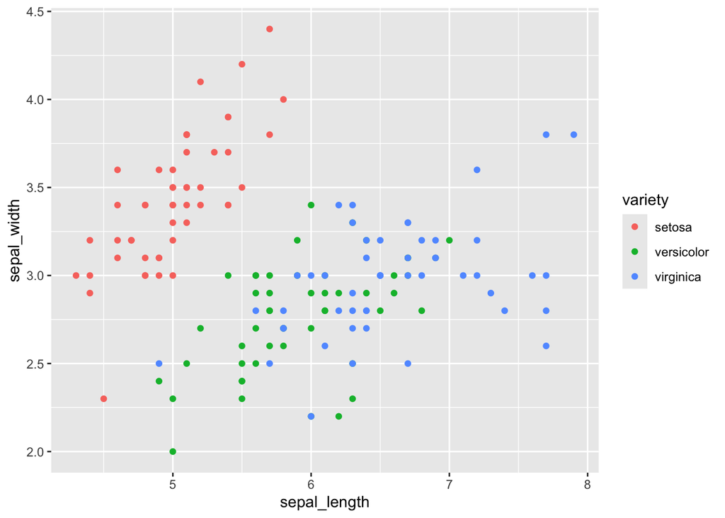

```r
ggplot(iris, aes(x = sepal_length, y = sepal_width, color = variety)) + geom_point()
```

### 2. Přidání titulku a popisků os

Upravte bodový graf tak, aby obsahoval název a popisky os x a y.

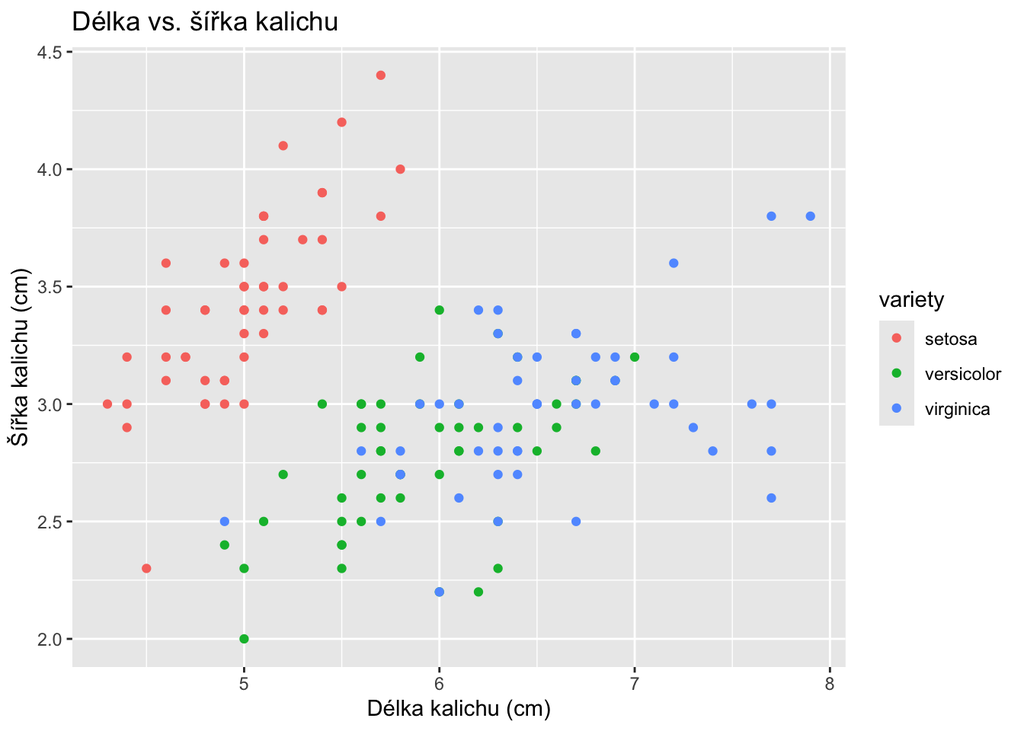

```r
ggplot(iris, aes(x = sepal_length, y = sepal_width, color = variety)) +
  geom_point() +
  ggtitle("Délka vs. šířka kalichu") +
  xlab("Délka kalichu (cm)") +
  ylab("Šířka kalichu (cm)")
```

### 3. Histogram

Vytvořte histogram délky okvětního lístku a použijte různé barvy pro jednotlivé druhy.

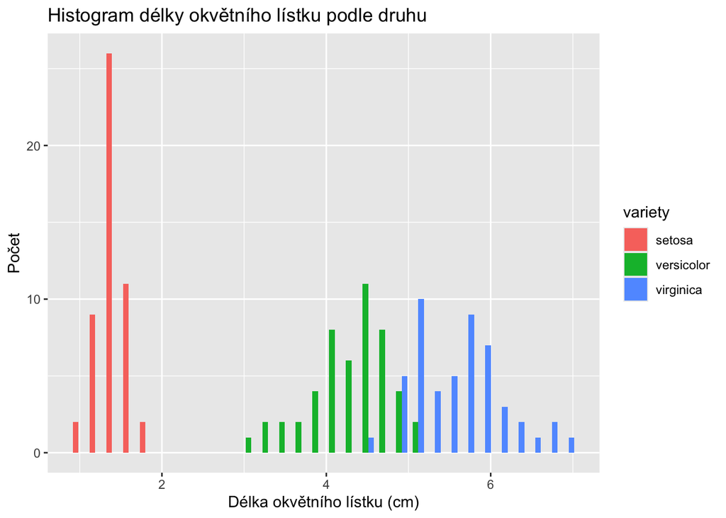

```r
ggplot(iris, aes(x = petal_length, fill = variety)) +
  geom_histogram(position = "dodge", bins = 30) +
  xlab("Délka okvětního lístku (cm)") +
  ylab("Počet") +
  ggtitle("Histogram délky okvětního lístku podle druhu")
```

### 4. Krabicový graf (Box Plot)

Vytvořte krabicový graf pro délku kalichu podle druhu.

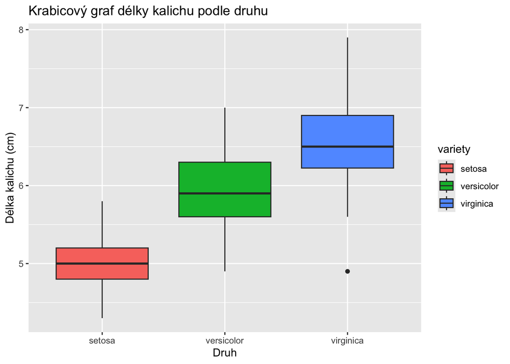

```r
ggplot(iris, aes(x = variety, y = sepal_length, fill = variety)) +
  geom_boxplot() +
  ggtitle("Krabicový graf délky kalichu podle druhu") +
  xlab("Druh") +
  ylab("Délka kalichu (cm)")
```

### 5. Dělení grafů pomocí `facet_grid`

Vytvořte samostatné bodové grafy délky vs. šířky okvětního lístku pro každý druh.

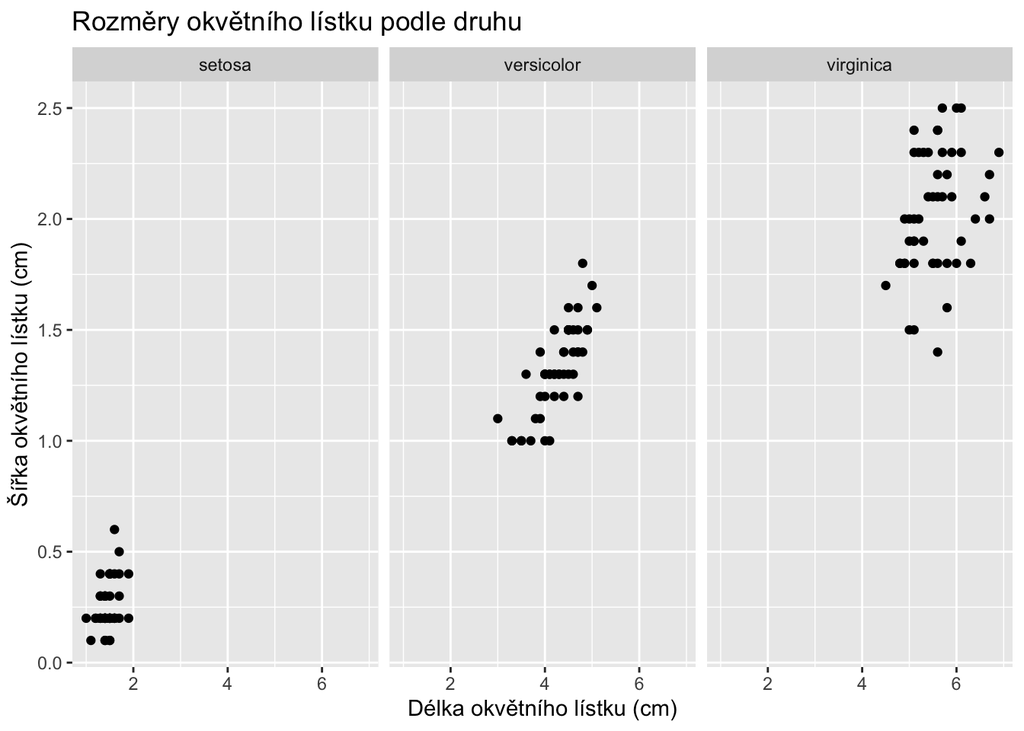

```r
ggplot(iris, aes(x = petal_length, y = petal_width)) +
  geom_point() +
  facet_grid(. ~ variety) +
  ggtitle("Rozměry okvětního lístku podle druhu") +
  xlab("Délka okvětního lístku (cm)") +
  ylab("Šířka okvětního lístku (cm)")
```

### 6. Hustotní graf (Density Plot)

Vytvořte hustotní graf šířky kalichu pro každý druh s odlišnými barvami.

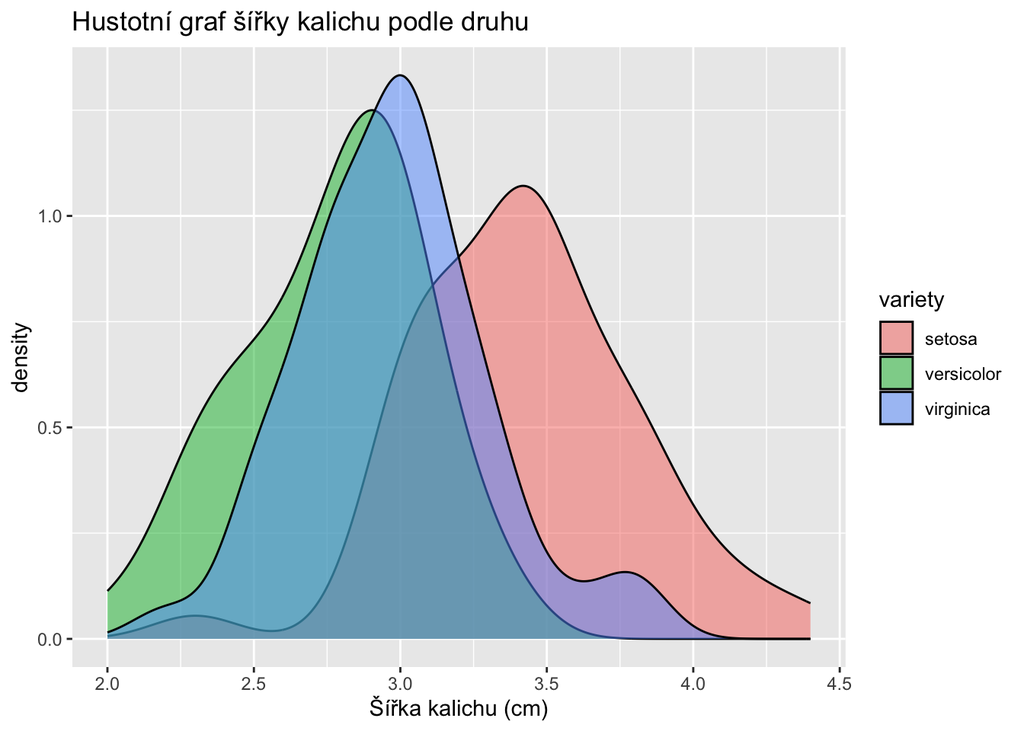

```r
ggplot(iris, aes(x = sepal_width, fill = variety)) +
  geom_density(alpha = 0.5) + # parametr alpha reguluje průhlednost barev (0 = průhledné, 1 = neprůhledné)
  ggtitle("Hustotní graf šířky kalichu podle druhu") +
  xlab("Šířka kalichu (cm)")
```

### 7. Spojnicový graf (Line Plot)

Vytvořte spojnicový graf průměrné délky okvětního lístku podle druhu.

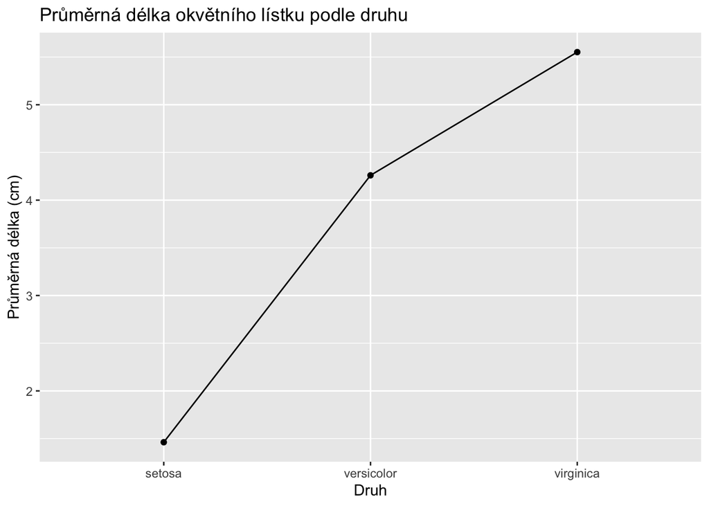

```r
iris_avg <- iris %>%
  group_by(variety) %>%
  summarize(avg_petal_length = mean(petal_length))

ggplot(iris_avg, aes(x = variety, y = avg_petal_length, group = 1)) +
  geom_line() +
  geom_point() +
  ggtitle("Průměrná délka okvětního lístku podle druhu") +
  xlab("Druh") +
  ylab("Průměrná délka (cm)")
```

### 8. Sloupcový graf (Bar Chart)

Vytvořte sloupcový graf počtu pozorování pro každý druh.

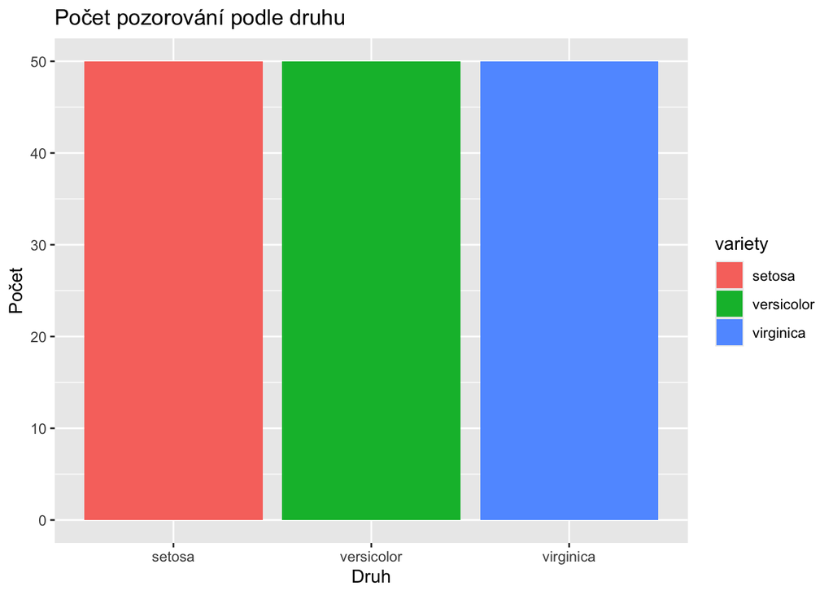

```r
ggplot(iris, aes(x = variety, fill = variety)) +
  geom_bar() +
  ggtitle("Počet pozorování podle druhu") +
  xlab("Druh") +
  ylab("Počet")
```

### 9. Úprava vzhledu grafu (Theme)

Upravte bodový graf délky kalichu vs. délky okvětního lístku tak, aby používal minimalistický styl a legenda byla umístěna dole.

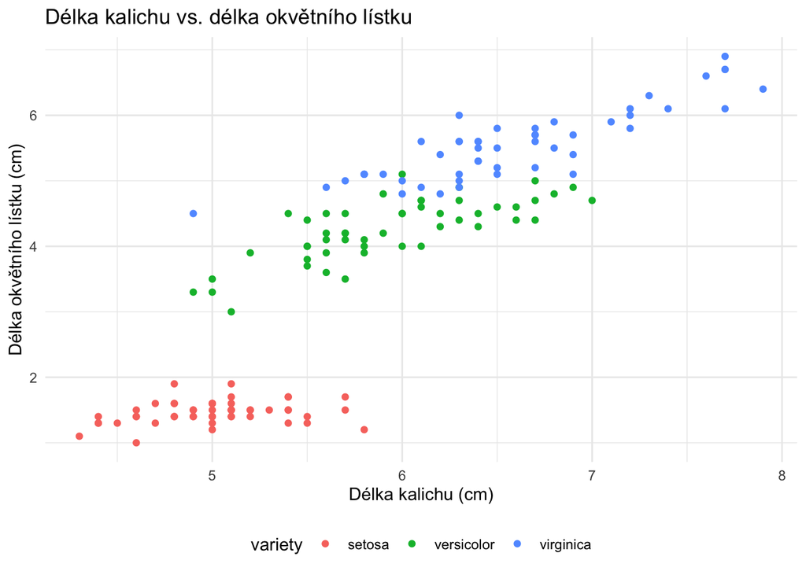

```r
ggplot(iris, aes(x = sepal_length, y = petal_length, color = variety)) +
  geom_point() +
  theme_minimal() +
  theme(legend.position = "bottom") +
  ggtitle("Délka kalichu vs. délka okvětního lístku") +
  xlab("Délka kalichu (cm)") +
  ylab("Délka okvětního lístku (cm)")
```

## Práce s kategoriálními daty pomocí `forcats`

V této části použijeme dataset `diamonds`, který obsahuje několik kategoriálních sloupců: `cut`, `color`, `clarity`.

```r
library(ggplot2)
diamonds$color
```

[output not shown]

[output cut: 1485 more lines]

### 1. Přeuspořádání úrovní faktoru podle mediánu ceny

Přeuspořádejte úrovně faktoru `cut` podle mediánu ceny (`price`) v sestupném pořadí.

```r
levels(diamonds$cut)
```

```
## [1] "Fair"      "Good"      "Very Good" "Premium"   "Ideal"
```

```r
diamonds$cut <- forcats::fct_reorder(diamonds$cut, diamonds$price, .fun = median, .desc = TRUE)

levels(diamonds$cut)
```

```
## [1] "Fair"      "Premium"   "Good"      "Very Good" "Ideal"
```

### 2. Sloučení méně častých úrovní v `color`

Sloučte méně časté úrovně faktoru `color` do kategorie “Other”, přičemž ponechte pouze 4 nejčastější barvy.

```r
levels(diamonds$color)
```

```
## [1] "D" "E" "F" "G" "H" "I" "J"
```

```r
diamonds$color <- forcats::fct_lump_n(diamonds$color, n = 4)

levels(diamonds$color)
```

```
## [1] "E"     "F"     "G"     "H"     "Other"
```

### 3. Sloučení úrovní faktoru `clarity`

Spojte úrovně faktoru `clarity` do širších kategorií:

- “Low” pro I1, SI2, SI1
- “Medium” pro VS2, VS1
- “High” pro VVS2, VVS1, IF

```r
levels(diamonds$clarity)
```

```
## [1] "I1"   "SI2"  "SI1"  "VS2"  "VS1"  "VVS2" "VVS1" "IF"
```

```r
diamonds$clarity <- forcats::fct_collapse(diamonds$clarity,
                                 Low = c("I1", "SI2", "SI1"),
                                 Medium = c("VS2", "VS1"),
                                 High = c("VVS2", "VVS1", "IF"))

levels(diamonds$clarity)
```

```
## [1] "Low"    "Medium" "High"
```

### 4. Přejmenování úrovní faktoru

Přejmenujte úrovně faktoru `cut` na srozumitelnější názvy:

- “Fair” → “Fair Cut”
- “Good” → “Good Cut”
- “Very Good” → “Very Good Cut”
- “Premium” → “Premium Cut”
- “Ideal” → “Ideal Cut”

```r
diamonds$cut <- forcats::fct_recode(diamonds$cut,
                           "Fair Cut" = "Fair",
                           "Good Cut" = "Good",
                           "Very Good Cut" = "Very Good",
                           "Premium Cut" = "Premium",
                           "Ideal Cut" = "Ideal")

levels(diamonds$cut)
```

```
## [1] "Fair Cut"      "Premium Cut"   "Good Cut"      "Very Good Cut"
## [5] "Ideal Cut"
```

### 5. Obrácení pořadí úrovní

Obraťte pořadí úrovní faktoru `clarity`.

```r
levels(diamonds$clarity)
```

```
## [1] "Low"    "Medium" "High"
```

```r
diamonds$clarity <- forcats::fct_rev(diamonds$clarity)

levels(diamonds$clarity)
```

```
## [1] "High"   "Medium" "Low"
```

### 6. Odstranění nepoužitých úrovní

```r
diamonds_subset <- diamonds %>%
  dplyr::filter(cut %in% c("Premium", "Ideal"))

diamonds_subset$cut <- forcats::fct_drop(diamonds_subset$cut)

levels(diamonds_subset$cut)
```

```
## character(0)
```

### 7. Převod číselné proměnné na faktor

Převeďte proměnnou `carat` na kategoriální faktor podle velikostních intervalů:

- 0.0–0.5 ct
- 0.5–1.0 ct
- 1.0–1.5 ct
- 1.5–2.0 ct
- nad 2.0 ct

```r
diamonds$carat_bin <- cut(diamonds$carat,
                          breaks = c(0, 0.5, 1, 1.5, 2, Inf),
                          labels = c("0-0.5", "0.5-1.0", "1.0-1.5", "1.5-2.0", "2.0+"))

levels(diamonds$carat_bin)
```

```
## [1] "0-0.5"   "0.5-1.0" "1.0-1.5" "1.5-2.0" "2.0+"
```

## Práce s textem pomocí `stringr`

```r
library(stringr)
```

### 1. Detekce vzorů v řetězcích

Najděte všechny řádky, kde sloupec `cut` obsahuje podřetězec “Good”.

```r
good_cut_diamonds <- diamonds[stringr::str_detect(diamonds$cut, "Good"), ]
head(good_cut_diamonds)
```

```
## # A tibble: 6 × 11
##   carat cut          color clarity depth table price     x     y     z carat_bin
##   <dbl> <ord>        <ord> <ord>   <dbl> <dbl> <int> <dbl> <dbl> <dbl> <fct>
## 1  0.23 Good Cut     E     Medium   56.9    65   327  4.05  4.07  2.31 0-0.5
## 2  0.31 Good Cut     Other Low      63.3    58   335  4.34  4.35  2.75 0-0.5
## 3  0.24 Very Good C… Other High     62.8    57   336  3.94  3.96  2.48 0-0.5
## 4  0.24 Very Good C… Other High     62.3    57   336  3.95  3.98  2.47 0-0.5
## 5  0.26 Very Good C… H     Low      61.9    55   337  4.07  4.11  2.53 0-0.5
## 6  0.23 Very Good C… H     Medium   59.4    61   338  4     4.05  2.39 0-0.5
```

### 2. Extrakce části řetězce

Vytvořte vektor ID ve formátu `"Diamond_ID-XXXXX"` a extrahujte pouze číselnou část.

```r
diamond_ids <- str_c("Diamond_ID-", rownames(diamonds))
extracted_ids <- stringr::str_extract(diamond_ids, "\\d+")
head(extracted_ids)
```

```
## [1] "1" "2" "3" "4" "5" "6"
```

### 3. Nahrazení podřetězců

Nahraďte všechna výskyty “Good” ve sloupci `cut` slovem “Decent”.

```r
head(diamonds$cut)
```

```
## [1] Ideal Cut     Premium Cut   Good Cut      Premium Cut   Good Cut
## [6] Very Good Cut
## Levels: Fair Cut < Premium Cut < Good Cut < Very Good Cut < Ideal Cut
```

```r
diamonds$cut <- stringr::str_replace(diamonds$cut, "Good", "Decent")
head(diamonds$cut)
```

```
## [1] "Ideal Cut"       "Premium Cut"     "Decent Cut"      "Premium Cut"
## [5] "Decent Cut"      "Very Decent Cut"
```

### 4. Rozdělení řetězců

Rozdělte řetězce typu `"1.5 carats"` na číselnou hodnotu a jednotku.

```r
carat_strings <- c("1.5 carats", "2.0 carats", "0.9 carats")
split_carat <- stringr::str_split(carat_strings, " ", simplify = TRUE)
carat_values <- as.numeric(split_carat[, 1])
carat_units <- split_carat[, 2]

head(carat_values)
```

```
## [1] 1.5 2.0 0.9
```

```r
head(carat_units)
```

```
## [1] "carats" "carats" "carats"
```

### 5. Délka řetězců

Spočítejte počet znaků v každé úrovni faktoru `cut`.

```r
cut_lengths <- stringr::str_length(diamonds$cut)
head(cut_lengths)
```

```
## [1]  9 11 10 11 10 15
```

### 6. Spojování řetězců

Spojte hodnoty ze sloupců `cut`, `color`, `clarity` do jednoho textového identifikátoru odděleného pomlčkami.

```r
diamond_id <- stringr::str_c(diamonds$cut, diamonds$color, diamonds$clarity, sep = "-")
head(diamond_id)
```

```
## [1] "Ideal Cut-E-Low"            "Premium Cut-E-Low"
## [3] "Decent Cut-E-Medium"        "Premium Cut-Other-Medium"
## [5] "Decent Cut-Other-Low"       "Very Decent Cut-Other-High"
```

### 7. Detekce číslic

Zjistěte, které řetězce ve vektoru obsahují číslice.

```r
mixed_strings <- c("carat 2.5", "weight", "price $500", "value 1000")
contains_digits <- stringr::str_detect(mixed_strings, "\\d")
contains_digits
```

```
## [1]  TRUE FALSE  TRUE  TRUE
```

### 8. Ořezání mezer

Odstraňte počáteční a koncové mezery ve vektoru popisů diamantů.

```r
diamond_descriptions <- c("  Ideal Cut  ", "  Premium Quality ", "Fair Cut ")
trimmed_descriptions <- stringr::str_trim(diamond_descriptions)
trimmed_descriptions
```

```
## [1] "Ideal Cut"       "Premium Quality" "Fair Cut"
```

### 9. Počet výskytů znaku

Spočítejte, kolikrát se vyskytuje písmeno `"e"` ve sloupci `cut` v celém datasetu.

```r
e_count <- stringr::str_count(diamonds$cut, "e")
total_e_count <- sum(e_count)
total_e_count
```

```
## [1] 81400
```

### 10. Opakování řetězce

Vytvořte řetězec, který opakuje slovo `"Diamond"` pětkrát.

```r
repeated_string <- stringr::str_dup("Diamond", 5)
repeated_string
```

```
## [1] "DiamondDiamondDiamondDiamondDiamond"
```

### 11. Změna velikosti písmen

Převeďte obsah sloupce `color` na velká písmena.

```r
head(diamonds$color)
```

```
## [1] E     E     E     Other Other Other
## Levels: E < F < G < H < Other
```

```r
diamonds$color <- stringr::str_to_upper(diamonds$color)
head(diamonds$color)
```

```
## [1] "E"     "E"     "E"     "OTHER" "OTHER" "OTHER"
```

### 12. Výběr části řetězce

Vezměte první tři znaky každé hodnoty ve sloupci `clarity`.

```r
clarity_subset <- stringr::str_sub(diamonds$clarity, 1, 3)
head(clarity_subset)
```

```
## [1] "Low" "Low" "Med" "Med" "Low" "Hig"
```

### 13. Doplňování řetězců nulami

Vytvořte ID diamantů a doplňte je zleva nulami tak, aby měly všechna ID pět číslic.

```r
diamond_ids <- stringr::str_pad(row.names(diamonds), width = 5, pad = "0")
head(diamond_ids)
```

```
## [1] "00001" "00002" "00003" "00004" "00005" "00006"
```

## Práce s datem a časem pomocí `lubridate`

```r
library(lubridate)
```

### 1. Parsování dat

Převeďte řetězec `"2023-08-15"` na objekt typu datum.

```r
date <- lubridate::ymd("2023-08-15")
date
```

```
## [1] "2023-08-15"
```

### 2. Získání komponent datumu

Z datumu `"2024-12-25"` získejte rok, měsíc a den.

```r
date <- lubridate::ymd("2024-12-25")
year <- lubridate::year(date)
month <- lubridate::month(date)
day <- lubridate::day(date)

year
```

```
## [1] 2024
```

```r
month
```

```
## [1] 12
```

```r
day
```

```
## [1] 25
```

### 3. Práce s různými formáty dat

Načtěte datum `"15-August-2023"` jako objekt typu datum.

```r
date <- lubridate::dmy("15-August-2023")
date
```

```
## [1] "2023-08-15"
```

### 4. Přičítání a odečítání časových intervalů

Přičtěte 3 měsíce a odečtěte 10 dní od datumu `"2023-01-01"`.

```r
date <- lubridate::ymd("2023-01-01")
date_plus_3_months <- date %m+% months(3)
date_minus_10_days <- date - days(10)

date_plus_3_months
```

```
## [1] "2023-04-01"
```

```r
date_minus_10_days
```

```
## [1] "2022-12-22"
```

### 5. Výpočet rozdílu mezi daty

Spočítejte počet dní mezi `"2023-01-01"` a `"2024-01-01"`.

```r
date1 <- lubridate::ymd("2023-01-01")
date2 <- lubridate::ymd("2024-01-01")
days_diff <- as.numeric(difftime(date2, date1, units = "days"))

days_diff
```

```
## [1] 365
```

### 6. Práce s datem a časem

Vytvořte objekt `datetime` pro `"2023-08-15 12:34:56"`.

```r
datetime <- lubridate::ymd_hms("2023-08-15 12:34:56")
datetime
```

```
## [1] "2023-08-15 12:34:56 UTC"
```

### 7. Získání komponent času

Z objektu `"2023-08-15 12:34:56"` získejte hodinu, minutu a sekundu.

```r
datetime <- lubridate::ymd_hms("2023-08-15 12:34:56")
hour <- lubridate::hour(datetime)
minute <- lubridate::minute(datetime)
second <- lubridate::second(datetime)

hour
```

```
## [1] 12
```

```r
minute
```

```
## [1] 34
```

```r
second
```

```
## [1] 56
```

### 8. Zaokrouhlení dat

Zaokrouhlete čas `"2023-08-15 12:34:56"` na celé hodiny.

```r
datetime <- lubridate::ymd_hms("2023-08-15 12:34:56")
rounded_datetime <- lubridate::round_date(datetime, unit = "hour")

rounded_datetime
```

```
## [1] "2023-08-15 13:00:00 UTC"
```

### 9. Zjištění dne v týdnu

Zjistěte den v týdnu pro datum `"2023-08-15"`.

```r
date <- lubridate::ymd("2023-08-15")
day_of_week <- lubridate::wday(date, label = TRUE)

day_of_week
```

```
## [1] Tue
## Levels: Sun < Mon < Tue < Wed < Thu < Fri < Sat
```

### 10. Převod časového pásma

Převeďte čas `"2023-08-15 12:34:56"` z UTC na časové pásmo `"America/New_York"`.

```r
datetime_utc <- lubridate::ymd_hms("2023-08-15 12:34:56", tz = "UTC")
datetime_ny <- lubridate::with_tz(datetime_utc, tzone = "America/New_York")

datetime_ny
```

```
## [1] "2023-08-15 08:34:56 EDT"
```

## Moderní práce s datovými rámci pomocí `tibble`

```r
library(tibble)
```

### 1. Vytvoření jednoduchého tibble

Vytvořte tibble se třemi sloupci: `Name` (text), `Age` (číslo), `Height` (číslo).

```r
people <- tibble::tibble(
  Name = c("Alice", "Bob", "Charlie"),
  Age = c(25, 30, 35),
  Height = c(160, 175, 168)
)

people
```

```
## # A tibble: 3 × 3
##   Name      Age Height
##   <chr>   <dbl>  <dbl>
## 1 Alice      25    160
## 2 Bob        30    175
## 3 Charlie    35    168
```

### 2. Přidání nového sloupce

Přidejte nový sloupec `Weight` do tibble `people`.

```r
people <- people %>%
  dplyr::mutate(Weight = c(55, 70, 68))

people
```

```
## # A tibble: 3 × 4
##   Name      Age Height Weight
##   <chr>   <dbl>  <dbl>  <dbl>
## 1 Alice      25    160     55
## 2 Bob        30    175     70
## 3 Charlie    35    168     68
```

### 3. Převod `data.frame` na `tibble`

Převeďte vestavěný datový rámec `mtcars` na `tibble`.

```r
mtcars_tibble <- tibble::as_tibble(mtcars)
mtcars_tibble
```

```
## # A tibble: 32 × 11
##      mpg   cyl  disp    hp  drat    wt  qsec    vs    am  gear  carb
##    <dbl> <dbl> <dbl> <dbl> <dbl> <dbl> <dbl> <dbl> <dbl> <dbl> <dbl>
##  1  21       6  160    110  3.9   2.62  16.5     0     1     4     4
##  2  21       6  160    110  3.9   2.88  17.0     0     1     4     4
##  3  22.8     4  108     93  3.85  2.32  18.6     1     1     4     1
##  4  21.4     6  258    110  3.08  3.22  19.4     1     0     3     1
##  5  18.7     8  360    175  3.15  3.44  17.0     0     0     3     2
##  6  18.1     6  225    105  2.76  3.46  20.2     1     0     3     1
##  7  14.3     8  360    245  3.21  3.57  15.8     0     0     3     4
##  8  24.4     4  147.    62  3.69  3.19  20       1     0     4     2
##  9  22.8     4  141.    95  3.92  3.15  22.9     1     0     4     2
## 10  19.2     6  168.   123  3.92  3.44  18.3     1     0     4     4
## # ℹ 22 more rows
```

### 4. Přístup ke sloupci v `tibble`

Získejte sloupec `mpg` z `mtcars_tibble` pomocí operátoru `$`.

```r
mpg_column <- mtcars_tibble$mpg
mpg_column
```

```
##  [1] 21.0 21.0 22.8 21.4 18.7 18.1 14.3 24.4 22.8 19.2 17.8 16.4 17.3 15.2 10.4
## [16] 10.4 14.7 32.4 30.4 33.9 21.5 15.5 15.2 13.3 19.2 27.3 26.0 30.4 15.8 19.7
## [31] 15.0 21.4
```

### 5. Přístup k řádkům v `tibble`

Zobrazte prvních 5 řádků tibble `mtcars_tibble`.

```r
first_five_rows <- mtcars_tibble[1:5, ]
first_five_rows
```

```
## # A tibble: 5 × 11
##     mpg   cyl  disp    hp  drat    wt  qsec    vs    am  gear  carb
##   <dbl> <dbl> <dbl> <dbl> <dbl> <dbl> <dbl> <dbl> <dbl> <dbl> <dbl>
## 1  21       6   160   110  3.9   2.62  16.5     0     1     4     4
## 2  21       6   160   110  3.9   2.88  17.0     0     1     4     4
## 3  22.8     4   108    93  3.85  2.32  18.6     1     1     4     1
## 4  21.4     6   258   110  3.08  3.22  19.4     1     0     3     1
## 5  18.7     8   360   175  3.15  3.44  17.0     0     0     3     2
```

### 6. Vytvoření tibble s různými typy dat

Vytvořte tibble s datem, logickou a textovou proměnnou.

```r
mixed_tibble <- tibble::tibble(
  Date = as.Date(c("2023-01-01", "2023-01-02", "2023-01-03")),
  Logical = c(TRUE, FALSE, TRUE),
  Category = c("A", "B", "C")
)

mixed_tibble
```

```
## # A tibble: 3 × 3
##   Date       Logical Category
##   <date>     <lgl>   <chr>
## 1 2023-01-01 TRUE    A
## 2 2023-01-02 FALSE   B
## 3 2023-01-03 TRUE    C
```

### 7. Přejmenování sloupců

Přejmenujte sloupce v `people` na `Full_Name`, `Age_Years`, `Height_cm`.

```r
people <- people %>%
  dplyr::rename(
    Full_Name = Name,
    Age_Years = Age,
    Height_cm = Height
  )

people
```

```
## # A tibble: 3 × 4
##   Full_Name Age_Years Height_cm Weight
##   <chr>         <dbl>     <dbl>  <dbl>
## 1 Alice            25       160     55
## 2 Bob              30       175     70
## 3 Charlie          35       168     68
```

### 8. Filtrování a výběr sloupců pomocí `filter` a `select`

Vyberte z `mtcars_tibble` pouze řádky, kde je `mpg` > 20, a zobrazte sloupce `mpg`, `hp`, `wt`.

```r
filtered_tibble <- mtcars_tibble %>%
  dplyr::filter(mpg > 20) %>%
  dplyr::select(mpg, hp, wt)

filtered_tibble
```

```
## # A tibble: 14 × 3
##      mpg    hp    wt
##    <dbl> <dbl> <dbl>
##  1  21     110  2.62
##  2  21     110  2.88
##  3  22.8    93  2.32
##  4  21.4   110  3.22
##  5  24.4    62  3.19
##  6  22.8    95  3.15
##  7  32.4    66  2.2
##  8  30.4    52  1.62
##  9  33.9    65  1.84
## 10  21.5    97  2.46
## 11  27.3    66  1.94
## 12  26      91  2.14
## 13  30.4   113  1.51
## 14  21.4   109  2.78
```

## Funkcionální programování s `purrr`

```r
library(purrr)
```

### 1. Aplikace funkce na každý prvek seznamu

Vytvořte seznam číselných vektorů a aplikujte funkci `mean` (průměr) na každý vektor.

```r
num_list <- list(c(1, 2, 3), c(4, 5, 6, 7), c(8, 9))
means <- purrr::map_dbl(num_list, mean)

means
```

```
## [1] 2.0 5.5 8.5
```

### 2. Mapování přes více seznamů

```r
list1 <- list(c(1, 2, 3), c(4, 5))
list2 <- list(c(10, 20, 30), c(40, 50))
sums <- purrr::map2(list1, list2, ~ .x + .x)

sums
```

```
## [[1]]
## [1] 2 4 6
##
## [[2]]
## [1]  8 10
```

### 3. Extrakce prvků ze seznamu seznamů

Získejte první prvek z každého podseznamu v seznamu seznamů.

```r
nested_list <- list(
  list(a = 1, b = 2),
  list(a = 3, b = 4),
  list(a = 5, b = 6)
)
first_elements <- purrr::map(nested_list, "a")

first_elements
```

```
## [[1]]
## [1] 1
##
## [[2]]
## [1] 3
##
## [[3]]
## [1] 5
```

### 4. Bezpečné použití funkcí

Použijte `safely` k aplikaci funkce, která může selhat (např. dělení), na seznam hodnot s ošetřením chyb.

```r
safe_divide <- safely(~ 10 / .x)

results <- purrr::map(list(2, 0, 5), safe_divide)
results
```

```
## [[1]]
## [[1]]$result
## [1] 5
##
## [[1]]$error
## NULL
##
##
## [[2]]
## [[2]]$result
## [1] Inf
##
## [[2]]$error
## NULL
##
##
## [[3]]
## [[3]]$result
## [1] 2
##
## [[3]]$error
## NULL
```

### 5. Rozbalení seznamu seznamů

Rozbalte seznam seznamů do jednoho seznamu.

```r
nested_list <- list(list(1, 2), list(3, 4), list(5, 6))
flat_list <- purrr::flatten(nested_list)

flat_list
```

```
## [[1]]
## [1] 1
##
## [[2]]
## [1] 2
##
## [[3]]
## [1] 3
##
## [[4]]
## [1] 4
##
## [[5]]
## [1] 5
##
## [[6]]
## [1] 6
```

### 6. Vytvoření `tibble` ze seznamu

Vytvořte `tibble` ze seznamu, kde každý prvek je vektor stejné délky.

```r
list_data <- list(
  Name = c("Alice", "Bob", "Charlie"),
  Age = c(25, 30, 35),
  Height = c(160, 175, 168)
)

people_tibble <- tibble::as_tibble(list_data)
people_tibble
```

```
## # A tibble: 3 × 3
##   Name      Age Height
##   <chr>   <dbl>  <dbl>
## 1 Alice      25    160
## 2 Bob        30    175
## 3 Charlie    35    168
```

### 7. Aplikace funkce na více argumentů

Máte-li dva číselné vektory, aplikujte funkci, která vypočítá maximum každé dvojice hodnot.

```r
vec1 <- c(1, 4, 3)
vec2 <- c(2, 3, 5)

max_values <- map2_dbl(vec1, vec2, max)
max_values
```

```
## [1] 2 4 5
```

### 8. Aplikace funkcí na sloupce datového rámce

Aplikujte funkci `mean` na každý sloupec datového rámce `mtcars`.

```r
mtcars_means <- purrr::map_dbl(mtcars, mean)

mtcars_means
```

```
##        mpg        cyl       disp         hp       drat         wt       qsec
##  20.090625   6.187500 230.721875 146.687500   3.596563   3.217250  17.848750
##         vs         am       gear       carb
##   0.437500   0.406250   3.687500   2.812500
```

### 9. Podmíněná aplikace funkce

Aplikujte funkci pouze na ty prvky seznamu, které splňují určitou podmínku (např. větší než 3).

```r
num_list <- list(1, 4, 3, 6, 2)

results <- purrr::map_if(num_list, ~ .x > 3, ~ .x * 2)
results
```

```
## [[1]]
## [1] 1
##
## [[2]]
## [1] 8
##
## [[3]]
## [1] 3
##
## [[4]]
## [1] 12
##
## [[5]]
## [1] 2
```

### 10. Redukce seznamu na jednu hodnotu

Použijte `reduce` k výpočtu kumulativního součinu hodnot v seznamu.

```r
num_list <- list(1, 2, 3, 4, 5)

product <- purrr::reduce(num_list, `*`)
product
```

```
## [1] 120
```

## Cvičení k `purrr`

```r
library(purrr)
```

### 1. Aplikace funkce na každý prvek seznamu

Vytvoř seznam číselných vektorů a spočítej průměr každého z nich.

```r
# TODO sem napiš svůj kód
```

### 2. Mapování přes více seznamů

Sečti odpovídající prvky dvou seznamů číselných vektorů.

```r
# TODO sem napiš svůj kód
```

### 3. Extrakce prvků ze seznamu seznamů

Získej první prvek z každého podseznamu.

```r
# TODO sem napiš svůj kód
```

### 4. Bezpečné použití funkcí

Bezpečně aplikuj dělení na seznam čísel (např. dělení 10 různými hodnotami, včetně nuly).

```r
# TODO sem napiš svůj kód
```

### 5. Rozbalení seznamu seznamů

Rozbal seznam složený ze tří podseznamů do jednoho.

```r
# TODO sem napiš svůj kód
```

### 6. Vytvoření tibble ze seznamu

Vytvoř `tibble`, kde každý prvek seznamu je vektor stejné délky.

```r
# TODO sem napiš svůj kód
```

### 7. Aplikace funkce na dvojice prvků

Pro dvě číselná pole zjisti maxima jednotlivých dvojic.

```r
# TODO sem napiš svůj kód
```

### 8. Aplikace na sloupce datového rámce

Aplikuj `mean()` na všechny sloupce `mtcars`.

```r
# TODO sem napiš svůj kód
```

### 9. Podmíněná aplikace funkce

Vynásob 2 pouze ta čísla v seznamu, která jsou větší než 3.

```r
# TODO sem napiš svůj kód
```

### 10. Redukce seznamu na jednu hodnotu

Spočítej součin všech hodnot v seznamu pomocí `reduce()`.

```r
# TODO sem napiš svůj kód
```